# RNA-seq analysis in R

Differential Expression of RNA-seq data

Stephane Ballereau, Dominique-Laurent Couturier, Mark Dunning, Abbi Edwards, Ashley Sawle

Last modified: 22 Jul 2020

## Recap of pre-processing

Where are we in the workflow? What has been done so far, step by step

What did Chandu do yesterday? mention filtering of low count genes

DESEQ2 - deseq vs edgeR, slightly different normalisation and filtering methods [here](https://mikelove.wordpress.com/2016/09/28/deseq2-or-edger/) by Mike Love

- help, forums, workflow page

## Start Coding ~ 15mins

have this copy pasted in at start

# Read the sample information into a data frame

sampleinfo <- read_tsv(“results/SampleInfo_Corrected.txt”)

# Read the data into R

seqdata <- read_tsv(“data/GSE60450_Lactation.featureCounts”, comment = “#”)

# Transform the data to matrix of counts

countdata <- as.data.frame(seqdata) %>% column_to_rownames(“Geneid”) %>% # turn the geneid column into rownames rename_all(str_remove, “.bam”) %>% # remove the “.bam” from the column names select(sampleinfo$Sample) %>% # keep sample columns using sampleinfo as.matrix()

# filter the data to remove genes with few counts

keep <- rowSums(countdata) > 5 countdata <- countdata[keep,]

Now that we are happy that the quality of the data looks good, proceed

- clean environment
- restart session
- make new script

### Load the data

```r
library(tidyverse)
library(DESeq2)
```

```r
## load the RData object we created in the previous session
load("../Course_Materials/Robjects/preprocessing.RData") # not correct path
```

Explain and view everything that has been loaded

Briefly sample info tab: status, celltype, 2 reps

```r
ls() # lists all loaded objects
```

```
## [1] "countdata"  "sampleinfo"
```

```r
dim(countdata)
```

```
## [1] 25369    12
```

```r
sampleinfo
```

```
## # A tibble: 12 x 4
##   FileName    Sample  CellType Status
##   <chr>       <chr>   <chr>    <chr>
## 1 MCL1.DG.bam MCL1.DG basal    virgin
## 2 MCL1.DH.bam MCL1.DH basal    virgin
## 3 MCL1.DI.bam MCL1.DI basal    pregnant
## # … with 9 more rows
```

### Create a DESeqDataSet object with the raw data

#### Creating the design model formula - 23 mins

Dom talked about this morning

what we think is affecting expression, so for us that would be the celltype and status

BUT for simplicity to learn workflow, simple model just status and ignore celltype, we will go into other models later

```r
## Use the standard R 'formula' syntax
design <- as.formula(~ Status)
```

~ means something on left is related to something on the right

- we don’t have to actually put anything on the left as we know its the expression data
- right side has to be a column header

#### model matrix, deseq2 makes it internally but we can get one to see what it looks like

```r
modelMatrix <- model.matrix(design, data = sampleinfo)
modelMatrix # look at it in console
```

it as automatically selected on condition as the intercept/baseline (alphabetical)

explain each coeffient

lactating is not the ideal intercept so lets change it to virgin, have to set the factor levels manually

#### fix virgin to intercept

```r
sampleinfo$Status <- factor(sampleinfo$Status,
                            levels = c("virgin", "pregnant", "lactate"))
modelMatrix <- model.matrix(design, data = sampleinfo)
modelMatrix
```

Now looks better

### Build a DESeq2DataSet - ~ 33 mins

own type of object which holds all of our data in one place so we don’t have to put all the bits in everytime

we give it the three things it needs

```r
## create the DESeqDataSet object
ddsObj.raw <- DESeqDataSetFromMatrix(countData = countdata,
                                     colData = sampleinfo,
                                     design = design)
```

Gives a warning, don’t worry

## MINI BREAK 5 mins - save script

# Differential expression analysis with DESeq2

## The `DESeq2` work flow ~ 40 mins

The main `DESeq2` work flow is carried out in 3 steps:

### Size factors

allows us to normalise between samples and compensate for sequencing depth and composition bias

### Dispersion

for each gene we need mean and dispersion (which relates mean to variance)

### Applying GM and running Wald test

test each gene between the sample groups

## START

First, Calculate the “median ratio” normalisation size factors…

keep same object, keep raw one safe

```r
ddsObj <- estimateSizeFactors(ddsObj.raw)
```

### Let’s have a look at that that did

```r
colData(ddsObj.raw)
```

```
## DataFrame with 12 rows and 4 columns
##            FileName      Sample    CellType   Status
##         <character> <character> <character> <factor>
## MCL1.DG MCL1.DG.bam     MCL1.DG       basal virgin
## MCL1.DH MCL1.DH.bam     MCL1.DH       basal virgin
## MCL1.DI MCL1.DI.bam     MCL1.DI       basal pregnant
## MCL1.DJ MCL1.DJ.bam     MCL1.DJ       basal pregnant
## MCL1.DK MCL1.DK.bam     MCL1.DK       basal lactate
## ...             ...         ...         ...      ...
## MCL1.LB MCL1.LB.bam     MCL1.LB     luminal virgin
## MCL1.LC MCL1.LC.bam     MCL1.LC     luminal pregnant
## MCL1.LD MCL1.LD.bam     MCL1.LD     luminal pregnant
## MCL1.LE MCL1.LE.bam     MCL1.LE     luminal lactate
## MCL1.LF MCL1.LF.bam     MCL1.LF     luminal lactate
```

```r
colData(ddsObj)
```

```
## DataFrame with 12 rows and 5 columns
##            FileName      Sample    CellType   Status sizeFactor
##         <character> <character> <character> <factor>  <numeric>
## MCL1.DG MCL1.DG.bam     MCL1.DG       basal virgin     1.293508
## MCL1.DH MCL1.DH.bam     MCL1.DH       basal virgin     1.198757
## MCL1.DI MCL1.DI.bam     MCL1.DI       basal pregnant   1.225709
## MCL1.DJ MCL1.DJ.bam     MCL1.DJ       basal pregnant   1.080972
## MCL1.DK MCL1.DK.bam     MCL1.DK       basal lactate    0.973883
## ...             ...         ...         ...      ...        ...
## MCL1.LB MCL1.LB.bam     MCL1.LB     luminal virgin     1.369562
## MCL1.LC MCL1.LC.bam     MCL1.LC     luminal pregnant   1.044485
## MCL1.LD MCL1.LD.bam     MCL1.LD     luminal pregnant   0.933974
## MCL1.LE MCL1.LE.bam     MCL1.LE     luminal lactate    0.570691
## MCL1.LF MCL1.LF.bam     MCL1.LF     luminal lactate    0.574564
```

its added extra size factors column that it can use to normalise between samples

We can use `plotMA` from `limma` to look at the data in an MA plot

MA plot is very common way to visualise data

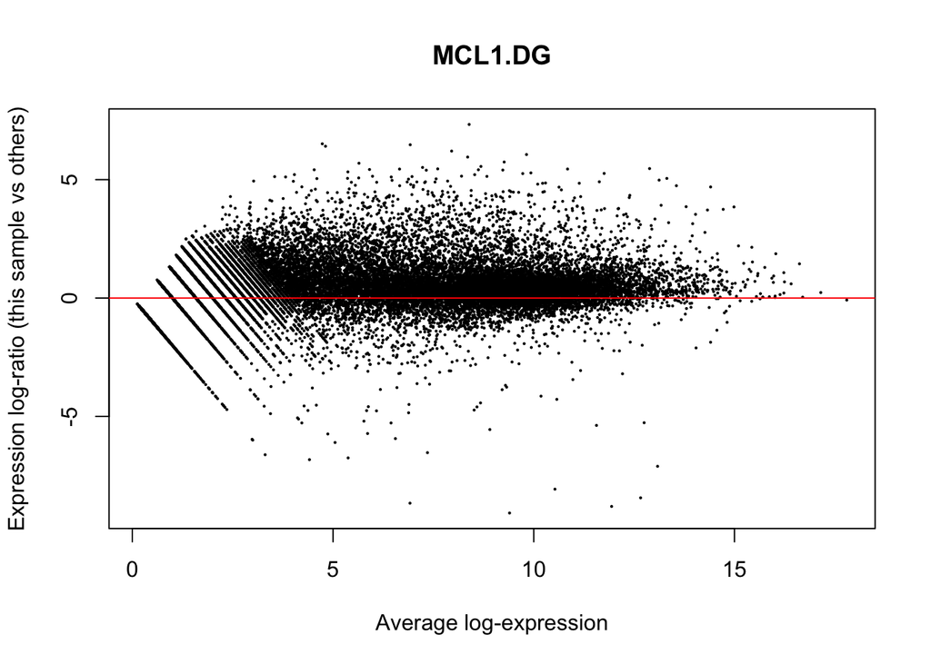

```r
logcounts <- log2(countdata + 1)

limma::plotMA(logcounts)
abline(h=0, col="red")
```

this plots first column

each point is gene

x axis is average expression

y axis is log ratio of expression of this sample vs. all other samples, so how different is this sample compared to other samples

A MAJOR ASSUMPTION with DEA is that in most conditions, most genes aren’t changing across samples. There are some edge cases where this might not be true an if that is the case you might not be able to use the size factors to normalise.

expectation: The plot should be centred on the zero line

RAW: This is centred above the zero line (size factor is above 1 in table)

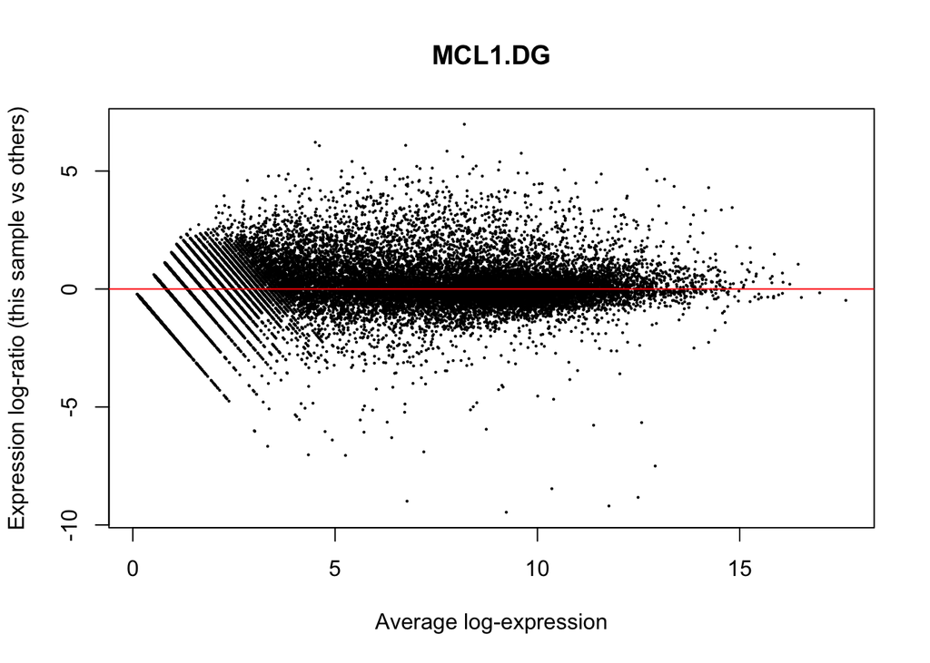

```r
normalizedCounts <- counts(ddsObj, normalized=TRUE)
logNormalizedCounts <- log2(normalizedCounts + 1)

limma::plotMA(logNormalizedCounts)
abline(h=0, col="red")
```

NEW: centred on zero line

## … next estimate dispersion … ~52 mins

```r
ddsObj <- estimateDispersions(ddsObj)
```

- gene wise , estimates for each gene but as we don’t have that many samples the estimate isn’t that great
- mean, by fitting the gene wise, gives something very conservative

SHOW DISPERSION PLOT

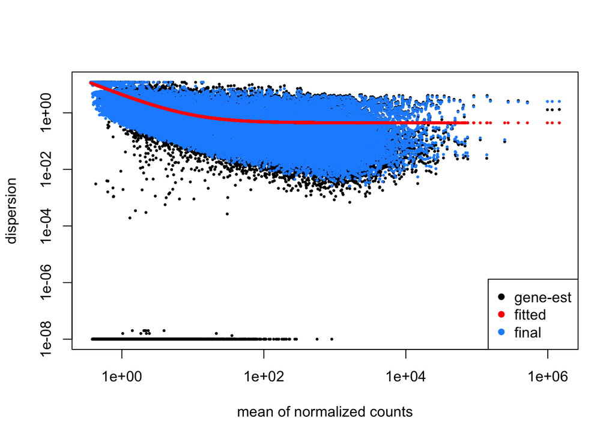

```r
plotDispEsts(ddsObj)
```

black dots are gene wise estimation red line is the fitting

The it does some sort of Bayesian statistics the shrink the gene wise estimates towards the fitted line to get a sort of inbetween that closer to the real dispersion, that is blue dots

## … finally, apply Negative Binomial GLM fitting and calculate Wald statistics

```r
ddsObj <- nbinomWaldTest(ddsObj)
```

## The `DESeq` command

In practice the 3 steps above can be performed in a single step using the `DESeq` wrapper function. Performing the three steps separately is useful if you wish to alter the default parameters of one or more steps, otherwise the `DESeq` function is fine.

```r
# Run DESeq
ddsObj <- DESeq(ddsObj.raw)
```

## MINI BREAK - 10 mins - Save Script

## Generate a results table

We can generate a table of differential expression results from the DDS object using the `results` function of DESeq2.

```r
res <- results(ddsObj, alpha=0.05) # need to tell it your FDR limit, 0.05 is typical

res # show in console
```

```
## log2 fold change (MLE): Status lactate vs virgin
## Wald test p-value: Status lactate vs virgin
## DataFrame with 25369 rows and 6 columns
##                       baseMean log2FoldChange     lfcSE       stat    pvalue
##                      <numeric>      <numeric> <numeric>  <numeric> <numeric>
## ENSMUSG00000051951  194.697167       0.234655  2.732631  0.0858714 0.9315687
## ENSMUSG00000102331    0.557693       2.218766  2.611789  0.8495197 0.3955922
## ENSMUSG00000025900    3.838125      -3.864560  1.954604 -1.9771573 0.0480238
## ENSMUSG00000025902   52.523551      -0.777627  0.992003 -0.7838953 0.4331015
## ENSMUSG00000098104    0.686876       0.567819  1.554715  0.3652239 0.7149443
## ...                        ...            ...       ...        ...       ...
## ENSMUSG00000094915    0.608461     -2.2137810  1.967784 -1.1250125  0.260584
## ENSMUSG00000079808    6.435068     -0.4505276  0.817495 -0.5511074  0.581560
## ENSMUSG00000095041 1685.461318     -0.0362203  0.904224 -0.0400568  0.968048
## ENSMUSG00000063897  443.698776      0.1796337  0.451321  0.3980177  0.690617
## ENSMUSG00000095742  665.855337     -0.0853626  0.613714 -0.1390919  0.889378
##                         padj
##                    <numeric>
## ENSMUSG00000051951  0.974958
## ENSMUSG00000102331        NA
## ENSMUSG00000025900  0.192165
## ENSMUSG00000025902  0.702193
## ENSMUSG00000098104        NA
## ...                      ...
## ENSMUSG00000094915        NA
## ENSMUSG00000079808  0.801230
## ENSMUSG00000095041  0.988683
## ENSMUSG00000063897  0.861026
## ENSMUSG00000095742  0.957371
```

Makes a DESeq results object.

This is table Dom was showing earlier at the start and end of his talk.

header - lactate over virgin

+ve FC means expression in lactate mice is higher than in virgin mice and vis versa

SE of FC

Wald statistic

pvalue - knowing th distribution of the wald statistic how likely is it that null hypothesis is true

FIRST GENE - small FC, high error, unsurprisingly higher pvalue

MTC - Dom explained some yesterday, we are doing lots of tests and each additional test adds error. The default in DeSeq2 is to use the benjamini-Hochberg method which gives us FDR.

As you can see this is very simple to run, you can put anything in and get numbers out, the point of Dom’s lecture earlier is almost to know what you don’t know and when you might want to find your friendly local bioinformatician or statistian.

### Independent filtering

You will notice that some of the adjusted p-values (`padj`) are NA.

Deseq does independent filtering, the genes with `NA` are the ones `DESeq2` has filtered out.

Best to read inthe deseq manual but briefly: runs all this and looks at your alpha and sees how many pass the threshold on FDR, then it goes back and looks at the baseMean and finds the gene with the lowest expression and excludes it. then it re does the MTC. Slowly it drops out genes until it gets to a point where most genes pass.

This might sound like cherrypicking but its ok because there is no coorelation between baseMean and pvalue.

Again best to read in manual but thats why there are NA’s.

### The default contrast of `results`

The `results` function has returned the results for the contrast “lactate vs virgin”. Let’s have a look at the model matrix to understand why `DESeq2` has given us this particular contrast.

```r
modelMatrix
```

```
##    (Intercept) Statuspregnant Statuslactate
## 1            1              0             0
## 2            1              0             0
## 3            1              1             0
## 4            1              1             0
## 5            1              0             1
## 6            1              0             1
## 7            1              0             0
## 8            1              0             0
## 9            1              1             0
## 10           1              1             0
## 11           1              0             1
## 12           1              0             1
## attr(,"assign")
## [1] 0 1 1
## attr(,"contrasts")
## attr(,"contrasts")$Status
## [1] "contr.treatment"
```

By default, `results` has returned the contrast encoded by the final column in the model matrix. `DESeq2` has the command `resultsNames` that allows us to view the contrasts that are available directly from the model matrix.

```r
resultsNames(ddsObj)
```

```
## [1] "Intercept"                 "Status_pregnant_vs_virgin"
## [3] "Status_lactate_vs_virgin"
```

Let’s just rename `res` so that we know which contrast results it contains.

```r
resLvV_status <- res
rm(res)
```

If we want a different contrast we can just pass the `results` function the name of the design matrix column that encodes it. Let’s retrieve the results for pregnant versus virgin

```r
resPvV_status <- results(ddsObj,
                  name="Status_pregnant_vs_virgin",
                  alpha = 0.05)
resPvV_status
```

```
## log2 fold change (MLE): Status pregnant vs virgin
## Wald test p-value: Status pregnant vs virgin
## DataFrame with 25369 rows and 6 columns
##                       baseMean log2FoldChange     lfcSE      stat    pvalue
##                      <numeric>      <numeric> <numeric> <numeric> <numeric>
## ENSMUSG00000051951  194.697167      -1.135371  2.733012 -0.415428  0.677828
## ENSMUSG00000102331    0.557693       0.963091  2.679825  0.359386  0.719307
## ENSMUSG00000025900    3.838125      -0.212930  1.695701 -0.125571  0.900072
## ENSMUSG00000025902   52.523551      -0.428587  0.987699 -0.433925  0.664343
## ENSMUSG00000098104    0.686876      -1.466301  1.690059 -0.867603  0.385612
## ...                        ...            ...       ...       ...       ...
## ENSMUSG00000094915    0.608461      -0.734876  1.881532 -0.390574  0.696113
## ENSMUSG00000079808    6.435068      -0.251606  0.786357 -0.319964  0.748996
## ENSMUSG00000095041 1685.461318      -0.170356  0.904165 -0.188412  0.850553
## ENSMUSG00000063897  443.698776       0.177684  0.450763  0.394184  0.693445
## ENSMUSG00000095742  665.855337      -0.131868  0.613446 -0.214962  0.829797
##                         padj
##                    <numeric>
## ENSMUSG00000051951  0.963150
## ENSMUSG00000102331        NA
## ENSMUSG00000025900        NA
## ENSMUSG00000025902  0.958286
## ENSMUSG00000098104        NA
## ...                      ...
## ENSMUSG00000094915        NA
## ENSMUSG00000079808  0.975952
## ENSMUSG00000095041  0.985066
## ENSMUSG00000063897  0.964635
## ENSMUSG00000095742  0.984082
```

How many differentially expressed genes are there at FDR < 0.05

```r
sum(resPvV_status$padj < 0.05)
```

```
## [1] NA
```

We need to remove `NA`’s as the genes that were filtered out by DESeq2 have `NA` in the in the `padj` column

```r
sum(resPvV_status$padj < 0.05, na.rm = TRUE) # not many degs but remember we didn't account for celltype
```

```
## [1] 723
```

doesn’t seem like many but we haven’t accounted for celltype

Let’s get the top 100 genes by adjusted p-value

```r
topGenesPvV <- as.data.frame(resPvV_status) %>%
    rownames_to_column("GeneID") %>%
    arrange(padj) %>%
    head(100)
topGenesPvV
```

### Exercise 1 - 1 hr 35 mins - give 20 mins - save script

> So far we have fitted a simple model considering just “Status”, but in reality we want to model the effects of both “Status” and “Cell Type”.

> Let’s start with the model with only main effects - an additive model with no interaction. The main assumption here is that the effect of the status on gene expression is the same in both types of cells.

> First we will recapitulate the above steps to generate a new DESeq2 object with the additive model. Then we will extract the results table for the contrast for “lactate v virgin”.
> 1. Load the raw data.  
>    Remember that we would like R to use ‘Virgin’ in the intercept of the mode, so we need to transform the Status into a factor in the sample sheet and set “Virgin” to be the first level.

> load(“Robjects/preprocessing.RData”) sampleinfo$Status <- factor(sampleinfo$Status, levels = c(“virgin”, “pregnant”, “lactate”))
> 2. Create the model

> design <- as.formula(~ CellType + Status)
> 2. Then build the DESeq from the raw data, the sample meta data and the model

> ddsObj.raw <- DESeqDataSetFromMatrix(countData = countdata, colData = sampleinfo, design = design)
> 3. Run the DESeq2 analysis

> ddsObj <- DESeq(ddsObj.raw)
> 4. Extract the default contrast - Lacate v Virgin

> resLvV <- results(ddsObj, alpha=0.05)

#### **Challenge 1**

```r
design <- as.formula(~ CellType + Status)
ddsObj.raw <- DESeqDataSetFromMatrix(countData = countdata,
                                     colData = sampleinfo,
                                     design = design)
ddsObj <- DESeq(ddsObj.raw)
resLvV <- results(ddsObj, alpha=0.05)
```

> 1. Obtain results for luminal vs basal. Call the new results object `resLvB`.

```r
resultsNames(ddsObj)
```

```
## [1] "Intercept"                 "CellType_luminal_vs_basal"
## [3] "Status_pregnant_vs_virgin" "Status_lactate_vs_virgin"
```

```r
resLvB <- results(ddsObj, alpha=0.05, name="CellType_luminal_vs_basal")
resLvB
```

```
## log2 fold change (MLE): CellType luminal vs basal
## Wald test p-value: CellType luminal vs basal
## DataFrame with 25369 rows and 6 columns
##                       baseMean log2FoldChange     lfcSE       stat       pvalue
##                      <numeric>      <numeric> <numeric>  <numeric>    <numeric>
## ENSMUSG00000051951  194.697167       -9.84263  0.940543 -10.464842  1.25285e-25
## ENSMUSG00000102331    0.557693       -2.17264  2.244933  -0.967799  3.33145e-01
## ENSMUSG00000025900    3.838125        4.16201  1.057538   3.935566  8.30008e-05
## ENSMUSG00000025902   52.523551       -2.67254  0.341351  -7.829312  4.90547e-15
## ENSMUSG00000098104    0.686876       -1.34806  1.458071  -0.924553  3.55198e-01
## ...                        ...            ...       ...        ...          ...
## ENSMUSG00000094915    0.608461       0.567067 1.7816216   0.318287  7.50267e-01
## ENSMUSG00000079808    6.435068      -0.758502 0.6674875  -1.136354  2.55809e-01
## ENSMUSG00000095041 1685.461318       2.581571 0.0977682  26.405015 1.20000e-153
## ENSMUSG00000063897  443.698776       1.056033 0.1218952   8.663448  4.57706e-18
## ENSMUSG00000095742  665.855337      -1.346141 0.2916639  -4.615383  3.92371e-06
##                            padj
##                       <numeric>
## ENSMUSG00000051951  1.92881e-24
## ENSMUSG00000102331           NA
## ENSMUSG00000025900  2.25325e-04
## ENSMUSG00000025902  3.85988e-14
## ENSMUSG00000098104           NA
## ...                         ...
## ENSMUSG00000094915           NA
## ENSMUSG00000079808  3.35755e-01
## ENSMUSG00000095041 4.84161e-151
## ENSMUSG00000063897  4.46283e-17
## ENSMUSG00000095742  1.28042e-05
```

> 2. How many significantly upregulated genes are there?

```r
sum(resLvB$padj < 0.05 & resLvB$log2FoldChange > 0, na.rm = TRUE)
```

```
## [1] 6410
```

#### **Challenge 2 - Contrasts**

> Suppose we want to find genes that are differentially expressed between **pregnant** and **lactate**. We don’t have a parameter that explicitly will allow us to test that hypothesis. We need to provide a contrast.

> Look at the help page for `results` (`?results`) and read about the `contrast` argument (also look at Example 1 at the bottom of the help page)

> Use the `contrast` argument to extract the results table for “pregnant v lactate”.

SHOW HELP PAGE

# Should be using the interaction model? - 2hrs 5mins latest

So far we have modelled gene expression as a function of status and cell type with an additive model.

Now look at how to use an interactionmodel and how to decide if we need one

Go Through Models Image

- status and celltype are interacting in some way to create additional changes

Let’s revisit PCA from yesterday

we are using vst, vst and rlog are mostly interchangable in this case but vst is slightly faster

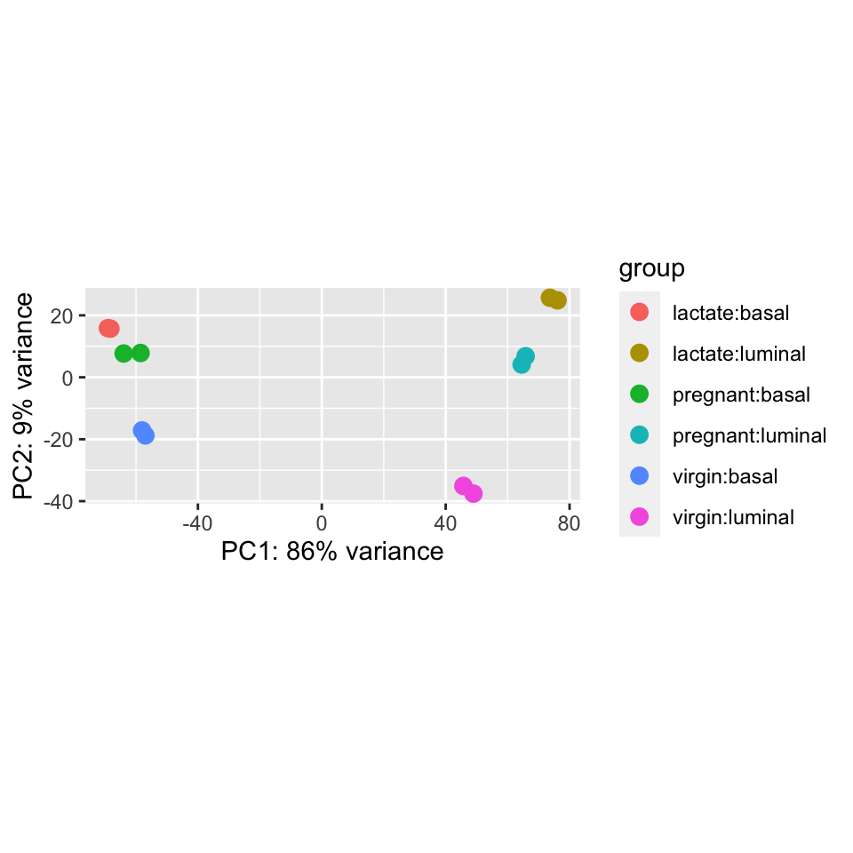

```r
vstcounts <- vst(ddsObj.raw, blind=TRUE)
plotPCA(vstcounts, intgroup=c("Status", "CellType")) # intgroup is what to colour by
```

Do yes/no question, do you think looking at the pca we need an interaction model?

spread is greater in the luminal cells than the basal cells so there might be an interaction there

A warning: There are lots of things that you could put into the model, but each extra factor reduces power so you need the simplest appropriate model. How do we know what that is?

## Comparing two design models

Let’s take a simple example to start with.

Suppose we thought that maybe `status` were irrelevant and really the only differences might be between cell types. We could fit a simpler model and this would give us more degrees of freedom and therefore more power, but how would we know if it was a better model of not?

We can compare two models using the “likelihood ratio test” (LRT).

To do so we provide the LRT with a simpler model (one with less parameters) than the one currently be used.

Currently `ddsObj` is using the model `~CellType + Status`. Here we want to compare to a model without the `Status` parameter: `~CellType`

```r
# create the simpler model
design.reduced <- as.formula(~ CellType )

# We want to test the simpler design against the more complex one
ddsObjC <- DESeq(ddsObj, test="LRT", reduced=design.reduced)
```

```
## found already estimated dispersions, replacing these
```

```r
resCvCS <- results(ddsObjC, alpha = 0.05)
resCvCS # look at it in the console
```

```
## log2 fold change (MLE): Status lactate vs virgin
## LRT p-value: '~ CellType + Status' vs '~ CellType'
## DataFrame with 25369 rows and 6 columns
##                       baseMean log2FoldChange     lfcSE      stat    pvalue
##                      <numeric>      <numeric> <numeric> <numeric> <numeric>
## ENSMUSG00000051951  194.697167       0.696569  0.755104   4.53253 0.1036987
## ENSMUSG00000102331    0.557693       1.842911  2.747250   0.40384 0.8171603
## ENSMUSG00000025900    3.838125      -2.862379  1.268975   5.80154 0.0549808
## ENSMUSG00000025902   52.523551      -0.698029  0.413168   2.94369 0.2295016
## ENSMUSG00000098104    0.686876       0.217999  1.693518   1.14087 0.5652807
## ...                        ...            ...       ...       ...       ...
## ENSMUSG00000094915    0.608461     -2.2382455  2.189425  1.552914  0.460033
## ENSMUSG00000079808    6.435068     -0.8526145  0.827529  0.915378  0.632744
## ENSMUSG00000095041 1685.461318      0.0272067  0.119549  2.149946  0.341307
## ENSMUSG00000063897  443.698776      0.0832803  0.149702  0.538020  0.764135
## ENSMUSG00000095742  665.855337     -0.4673463  0.357462  1.595263  0.450394
##                         padj
##                    <numeric>
## ENSMUSG00000051951  0.187485
## ENSMUSG00000102331        NA
## ENSMUSG00000025900  0.113755
## ENSMUSG00000025902  0.347704
## ENSMUSG00000098104        NA
## ...                      ...
## ENSMUSG00000094915        NA
## ENSMUSG00000079808  0.726170
## ENSMUSG00000095041  0.464788
## ENSMUSG00000063897  0.831245
## ENSMUSG00000095742  0.568343
```

header: what comparison we are doing

The null hypothesis is that there is no significant difference between the two models, i.e. the simpler model is sufficient to explain the variation in gene expression between the samples. If thats true we might as well use the simpler model and get more power.

```r
# lets see how many
sum(resCvCS$padj < 0.05, na.rm=TRUE)
```

```
## [1] 7948
```

7948 genes for which complex model is better (not surprising)

There will be some genes for which there isn’t a difference, this model will never be best for every gene but we have to pick one.

So How Many? …seems sensible

This was simple vs additive, we actually want additive vs interaction, and thats down to you

### Exercise 2 - 2hrs 30mis latest - give 20mins - save script

> When we looked at the PCA it did seem that an interaction model might be warranted. Let’s test that.

#### Challenge

> 1. Create a new DESeq2 object using a model with an interaction between CellType and Status. The model formula should be

>    `~CellType + Status + CellType:Status`

>    where `CellType:Status` is the parameter for the interaction beteween CellType and Status.  
>    Look back at the code at the beginning of Exercise 1 to remind you how to do this.

> Note that `*` can be used as shortcut to add the interaction term, e.g. `~CellType * Status`, however, writing out in long form is clearer here.
> 2. Use the LRT to compare this to the simpler additive model (`~CellType + Status`)
> 3. Extract a table of results using `results`.

#### Questions:

> For how many genes is interaction model a better fit?

> Do you think we need to use the interaction model for this analysis?

> Do you think the experimental design is good enough to include the interaction?

> If not, why and how would you change it?

9119 genes different

yes/no - should we use th interaction model?

yes/no - do you think the design of this experiment is sufficient to assess the interaction?

In chat, how would you fix it?

more reps, with simple model we would have 4 reps per group, if we go more complex its only 2

As you can see, DESeq is dangerously simple, have to be careful and only interpret within the limitations

There is lots more to deseq2 and you should read the manual for more

SAVE SCRIPT

## Finally save the results in a new RData object

```r
save(resLvV, ddsObj, sampleinfo, file="results/DE.RData")
```